# The STUpump (v0.1): specification, description and examples

Dan Dediu, ddediu@gmail.com

2020-01-19 20:21:50

## Introduction

This is a proof-of-concept implementation of an off-line mechanism for computing and plotting various types of CMAs for groups of patients and medications/events for downstream use and display.

## The input tables

The input tables are (the table columns are required unless specified otherwise):

- the table of events (denoted as `events`) which contains all the events in the format expected by `AdhereR`, namely:
  - `pat_id`: the patient’s unique ID
  - `event_id`: (optional) the event’s unique ID (either within a given patient or globally)
  - `date`: the event date (in the yyyy-mm-dd format)
  - `perday`: (optional) the dosage per day
  - `category`: (optional) the medication name
  - `duration`: the duration in days
- the table of actions (denoted as `actions`) which contains the definitions of all the possible actions to be performed:
  - `action_id`: the actions’s unique ID
  - `action`: the actual action to be performed as the name of an `AdhereR` CMA function (e.g., `CMA1` or `CMA_per_episode`), possibly preceded by `plot.` (e.g., `plot.CMA0`)
  - `params`: the (optional) extra parameters allowing the customisation of the action, as meaningful parameters to the corresponding `AdhereR` function (e.g., for `plot.CMA_per_episode` one can pass `CMA.to.apply="CMA1", maximum.permissible.gap=90`)
- the table of medication classes (denoted as `classes`) which contains the definitions of all the combinations of medications that may be used to trigger actions:
  - `medclass_id`: the class unique ID
  - `class`: the actual definition of the class using a language described below
- the table of processingss (denoted as `procs`) which contains the action(s) that are to be done for a particular patient and type of events:
  - `proc_id`: the processing’s unique ID
  - `pat_id`: the ID of the patient (in table `events`) for which this applies (the special symbol `*` means “any patient”)
  - `medclass_id`: the ID of the class (in table `classes`) for which this applies (the special symbol `*` means “any class”)
  - `action_id`: the ID of the action (in table `actions`) to be done (the special symbol `*` means “the default action” – i.e., the action(s) corresponding to `pat_id` = `*` and `medclass_id` = `*`)
- the table of updates (denoted as `updated`) which contains list of patient IDs which do have updated info (i.e., those for which a re-computation should be done) or all (if empty):
  - `pat_id`: the IDs of the patients for which updated info requires re-evaluation and plotting

## The output tables

As a result of the processing, there are the following output tables:

- the table contaning the main results (denoted as `res_main`) which contains the simple CMAs (if any) and the plots (if any):
  - `result_id`: the unique ID identifying one row in this table
  - `pat_id`: the ID of the patient (in table `events`) to which this result applies
  - `proc_id`: the unique ID of the processing (in table `procs`) that has been applied
  - `proc_id_default`: for the “default” processings, these might be resolved to more than one processing, and this column holds the ID of the default processing applied (see below for details)
  - `estimate`: the actual numeric estimate of the simple CMA (if any) or NULL for complex CMAs, plots and for failures
  - `estimate_type`: the type of the CMA: `simple`, `sliding window` and `per episode`
  - `plot_jpg`: a “BLOB” column containing the plot (if any) as an actual JPEG image (or NULL if no plot)
  - `plot_html`: a “BLOB” column containing the plot (if any) as a self-contained HTML/CSS/JavaScript/SVG page + fall-back JPEG image as a single ZIP archive (or NULL if no plot)
- the table contaning the results for the sliding window CMAs (denoted as `res_slid_wnd`):
  - `result_id`: the unique ID identifying the results (= row) in the main results table `res_main` to which these estimates correspond
  - `pat_id`: the ID of the patient (in table `events`) to which this result applies
  - `window_id`: the unique ID (within this estimate) of the sliding window
  - `window_start`: the start date (in the yyyy-mm-dd format) of the sliding window
  - `window_end`: the end date (in the yyyy-mm-dd format) of the sliding window
  - `estimate`: the actual numeric estimate of the simple CMA for this particular sliding window
- the table contaning the results for the per episode CMAs (denoted as `res_per_epi`):
  - `result_id`: the unique ID identifying the results (= row) in the main results table `res_main` to which these estimates correspond
  - `pat_id`: the ID of the patient (in table `events`) to which this result applies
  - `episode_id`: the unique ID (within this estimate) of the episode
  - `episode_start`: the start date (in the yyyy-mm-dd format) of the episode
  - `gap_days`: the episode’s gap days
  - `episode_duration`: the episode’s duration in days
  - `episode_end`: the end date (in the yyyy-mm-dd format) of the episode
  - `estimate`: the actual numeric estimate of the simple CMA for this particular episode

## The configration file

There is an [YAML](https://yaml.org/) configuration file which specifies various user-customisable things, such as:

- the details of the database to be used (e.g., name, type, host, username, password…)
- the actual names of the tables (e.g., table `events` migh be called “prescriptions_db”) and of their columns (e.g., `pat_id` in `events` migh be called “PID”)

as well as global parameters such as `use_defaults` (for patients that have specific actions defined, should we also apply the default actions?) and `table_prefix` (some databases might need to prefix the table names with a short string such as “dbo.”).

The configuration file is read once and used throughout the processing. And example using `SQLite` is available here.

## How it works

Here we describe the conceptual process (i.e., it is possible that in practice this is optimised or slightly different). For each patient in the `updated` table:

1. retreive any *specific* processing(s) that may apply (i.e., select those rows from `procs` that match the `pat_id`)
2. if `use_defaults` = `TRUE`, also retreive the *default* processings (i.e., those that specify `*` as `pat_id`)
3. if there are processings to be applied, retreive the patient’s full data from the `events` table (i.e., those rows with matching `pat_id`)
4. for each processing, select the *events* that fit it (see below how that works)
5. if there are such events, feed them to the defined *action*:
   1. if the action is `CMA0`, nothing is to be done
   2. if the action is any other simple CMA, then estimate it and save the resulting numeric estimate in the main results table `res_main`
   3. if the action is a complex CMA, then estimate it and save the resulting numeric estimates in the sliding window (`res_slid_wnd`) and per episode (`res_per_epi`) results tables, respectively, making sure the `result_id` points back to the appropriate `res_main` row
   4. if the action is a plot, save the JPEG and HTML plots as BLOBs in the `res_main` table and the resulting numeric estimates (except for `CMA0`) as described above (points b and c)

## The medication classes

One mechanism for matching individual events/prescriptions/dispensations to specific actions is represented by *medication classes*. A medication class (or simply “class”) is a logical expression defining a combination of medication names and doses.

For example, we may define a simple class of painkillers (in the `classes` table) as:

| medclass_id | class |
| --- | --- |
| simple painkillers | `aspirin` \| `paracetamol` |

and we want that for all patients which have this class to compute `CMA2` (in the `procs` table):

| proc_id | pat_id | medclass_id | action_id |
| --- | --- | --- | --- |
| 77 | * | simple painkillers | CMA2 |

Please note that the actual name of the medication must be included between backticks `...`!

However, we might want to also have a larger class of painkillers, so we could add a new entry to the `classes` table:

| medclass_id | class |
| --- | --- |
| simple painkillers | `aspirin` \| `paracetamol` |
| all painkillers | {simple painkillers} \| `nurofen` |

where we re-use (i.e., refer to) the defintion of “simple painkillers” using the {…} construction. And for this we want to do `CMA3`, so we add a new processing:

| proc_id | pat_id | medclass_id | action_id |
| --- | --- | --- | --- |
| 77 | * | simple painkillers | CMA2 |
| 78 | * | all painkillers | CMA3 |

But aspirine can have other uses and we want to make a distinction based on its dose, so we change the defintion of the “simple painkillers” to apply only to high doses of aspirin only:

| medclass_id | class |
| --- | --- |
| simple painkillers | #`aspirin` > 200 \| `paracetamol` |
| all painkillers | {simple painkillers} \| `nurofen` |

and add a new use in hypertension:

| medclass_id | class |
| --- | --- |
| simple painkillers | #`aspirin` > 200 \| `paracetamol` |
| all painkillers | {simple painkillers} \| `nurofen` |
| hypertension | #`aspirin` <= 100 |

The special symbol # means the dose of the following medication (or combination thereof – thus we can also say something like #{simple painkillers} >= 300).

Finally, for a given patient, we may want to define an action for all other medications not matched by any specific class: in this case we must add a line containing the special symbol ?:

| proc_id | pat_id | medclass_id | action_id |
| --- | --- | --- | --- |
| 77 | * | simple painkillers | CMA2 |
| 78 | * | all painkillers | CMA3 |
| 79 | * | ? | pCMA0 |

The actions refered to by their `action_id` are of course defined in the `actions` table:

| action_id | action | params |
| --- | --- | --- |
| CMA2 | CMA2 |  |
| CMA3 | CMA3 |  |
| pCMA0 | plot.CMA0 | show.legend=FALSE |

The special class:

| medclass_id | class |
| --- | --- |
| * | * |

must always be defined and refers to the default class (i.e., anything).

The classes can use the full power of logical and arithmetic expressions, with the following conventions:

- *equal* can be any of: “==”, “IS”, “is”, “EQUAL”, “equal”, “=”
- *different* can be any of: “!=”, “IS NOT”, “is not”, “NOT EQUAL”, “not equal”, “DIFFERENT”, “different”, “<>”, “≠”
- *and* can be any of: “&”, “AND”, “and”, “&&”
- *or* can be any of: “|”, “OR”, “or”, “||”
- *not* can be any of: “!”, “NOT”, “not”, “^”, “~”, “¬”
- *dose of* can be any of: “#”, “DOSE”, “dose”
- *less than* can be any of: “<”, “LESS THAN”, “less than”, “LE”, “le”
- *less or equal than* can be any of: “<=”, “LESS THAN OR EQUAL”, “less than or equal”, “LEQ”, “leq”, “≤”
- *greater than* can be any of: “>”, “GREATER THAN”, “greater than”, “GE”, “ge”
- *greater or equal than* can be any of: “>=”, “GREATER THAN OR EQUAL”, “greater than or equal”, “GEQ”, “geq”, “≥”
- *not otherwise covered* can be: “?”, “OTHERWISE”, “otherwise”, “ELSE”, “else”
- *parantheses*: “(” and “)”
- *arithmetic operators*: “+”, “-”, “*”, “/”, “%%”, “^”

In fact, these expressions are transformed into `R` expressions and evaluated in a safe environment which has access only to logical, arithmetic and mathematical functions and operators.

## An example

We will use here the built-in dataset `med.events` to construct a database in `SQLite`:

### Set-up

```r
spec_file <- "./STUpump-SQLite-inRAM.yml"; # the YAML pec file
STUpump_version <- "0.1"; # the version

source("./SQL_queries.R", echo=FALSE); # load the SQL-specific stuff
```

### The YAML config file

Let’s see the YAML config file:

```r
cat(readLines(spec_file), sep = '\n')
```

```
##################################################################################
#
# YAML configuration file to be used by the STUpump
#
# Specifies not only the database and the credentials needed to acces it,
# but also various attributes of the database (mostly table and column names).
#
# (c) 2020, Dan Dediu, ddediu@gmail.com
#
##################################################################################


title: STUpump using a test SQLite database


# Global parameters:
globals:
  use_defaults: true # if a patient has specific processings defined, do we also apply the defaults or nor (the default is yes)

# Database-wide parameters:
database:
  type:  SQLite # type of SQL database server; can be MariaDB, MySQL, SQLite or MSSQL
  host:  null   # host name or IP (for SQLite this is the path to the file)
  DSN:   null   # server DSN (normally used with MSSQL)
  name:  ":memory:" # database's name (for SQLite this is the path to the file or :memory: for an in-RAM database)
  user:  null   # username
  psswd: null   # password; using double quotes to allow special characters (which must be escaped with a backslash)


# Parameters specific to the various tables (NB, not all columns can be changed by the user; e.g., table procs contains a patient ID but this uses the column name defined for table events):
tables:
  # Is there a prefix required to access the tables?
  table_prefix: null # sometimes the table name must be preceded by a prefix (if not, this is simply null)

  # The table contaning the actual events in the format needed by AdhereR:
  events:
    name:       in_events  # table name
    patient_id: pat_id     # name of the column containing the patient's unique id
    date:       date       # name of the column containing the prescription dates
    perday:     perday     # name of the column containing the dosage
```

[output cut: 36 more lines]

```
    estimate:     estimate         # the name of the column containing the window's estimated CMA

  # The table contaning the per episode results:
  per_episode_results:
    name:             out_res_per_epi  # table name
    episode_id:       episode_id       # the name of the column containing the episode's unique is
    episode_start:    episode_start    # the name of the column containing the episode's start date
    gap_days:         gap_days         # the name of the column containing the episode's gap days
    episode_duration: episode_duration # the name of the column containing the episode's duration
    episode_end:      episode_end      # the name of the column containing the episode's duration
    estimate:         estimate         # the name of the column containing the episode's estimated CMA

  # The table specifying which patients have updated info (i.e., which patients to process) -- can be missing if all the patients have to be processed:
  updated_info:
    name:       in_updated # table name
```

### Create the demo database

```r
# Create the test database:
stu_db <- SQL_db(spec_file, check_db=FALSE, preprocess_db=FALSE);
```

```
## ## Reading and parsing the config file './STUpump-SQLite-inRAM.yml' ##
##
## Config: using 'globals:use_defaults' = 'TRUE'.
##
## Config: read 'database:type' = 'sqlite'.
## Config: read 'database:host' = ''.
## Config: read 'database:DSN' = ''.
## Config: read 'database:user' = ''.
## Config: read 'database:psswd' = '***'.
## Config: read 'database:name' = ':memory:'.
##
## Config: read 'table:table_prefix' = ''.
## Config: read 'table:events:name' = 'in_events'.
## Config: read 'table:events:patient_id' = 'pat_id'.
## Config: read 'table:events:date' = 'date'.
## Config: read 'table:events:perday' = 'perday'.
## Config: read 'table:events:category' = 'category'.
## Config: read 'table:events:duration' = 'duration'.
##
## Config: read 'table:actions:name' = 'in_actions'.
## Config: read 'table:actions:action_id' = 'action_id'.
## Config: read 'table:actions:action' = 'action'.
## Config: read 'table:actions:params' = 'params'.
##
## Config: read 'table:med_classes:name' = 'in_classes'.
## Config: read 'table:med_classes:medclass_id' = 'medclass_id'.
## Config: read 'table:med_classes:class' = 'class'.
##
## Config: read 'table:processes:name' = 'in_classes'.
## Config: read 'table:processes:procid' = 'procid'.
##
## Config: read 'table:results:name' = 'out_res_main'.
## Config: read 'table:results:result_id' = 'result_id'.
## Config: read 'table:results:estimate' = 'estimate'.
## Config: read 'table:results:estimate_type' = 'estimate_type'.
## Config: read 'table:results:plot_jpg' = 'plot_jpg'.
## Config: read 'table:results:plot_html' = 'plot_html'.
##
## Config: read 'table:sliding_windows_results:name' = 'out_res_slid_wnd'.
## Config: read 'table:sliding_windows_results:window_id' = 'window_id'.
## Config: read 'table:sliding_windows_results:window_start' = 'window_start'.
## Config: read 'table:sliding_windows_results:window_end' = 'window_end'.
## Config: read 'table:sliding_windows_results:estimate' = 'estimate'.
##
## Config: read 'table:per_episode_results:name' = 'out_res_per_epi'.
## Config: read 'table:per_episode_results:episode_id' = 'episode_id'.
## Config: read 'table:per_episode_results:episode_start' = 'episode_start'.
## Config: read 'table:per_episode_results:gap_days' = 'gap_days'.
## Config: read 'table:per_episode_results:episode_duration' = 'episode_duration'.
## Config: read 'table:per_episode_results:episode_end' = 'episode_end'.
## Config: read 'table:per_episode_results:estimate' = 'estimate'.
##
## Config: read 'table:updated_info:name' = 'in_updated'.
##
## ## Finished parsing the config file ##
##
## Disconnect: database connection already stopped or never made...
```

```
## Connect: successful connection to the database...
## Reset: database results tables truncated...
```

```r
create_test_database(stu_db);
```

```
## Creating the test database dervied from AdhereR::med.events...
## Finished creating the test database...
```

### View the input tables

Let’ see how this demo database looks like, and in particular the *input* (“in_”) tables:

```r
# Display the tables it contains:
list_tables(stu_db);
```

```
## [1] "in_actions"       "in_classes"       "in_events"
## [4] "in_procs"         "in_updated"       "out_res_main"
## [7] "out_res_per_epi"  "out_res_slid_wnd" "sqlite_sequence"
```

```r
# Look at the `events` table (here called "in_events", as per the YAML config file)
# "in" means "input":
get_cols_info(stu_db, "in_events"); # column names, types and number of rows
```

| table | nrow | column | type | null | key |
| --- | --- | --- | --- | --- | --- |
| in_events | 1080 | pat_id | VARCHAR(256) | FALSE | FALSE |
| in_events | 1080 | date | DATE | FALSE | FALSE |
| in_events | 1080 | perday | INT | FALSE | FALSE |
| in_events | 1080 | category | VARCHAR(1024) | TRUE | FALSE |
| in_events | 1080 | duration | INT | TRUE | FALSE |

```r
sqlQ(stu_db, "SELECT * FROM in_events LIMIT 50;"); # first N entries
```

| pat_id | date | perday | category | duration |
| --- | --- | --- | --- | --- |
| 1 | 2033-04-26 | 4 | medA | 50 |
| 1 | 2033-07-04 | 4 | medB | 30 |
| 1 | 2033-08-03 | 4 | medB | 30 |
| 1 | 2033-08-17 | 4 | medB | 30 |
| 1 | 2033-10-13 | 4 | medB | 30 |
| 1 | 2033-10-16 | 4 | medB | 30 |
| 1 | 2033-11-23 | 4 | medB | 30 |
| 1 | 2034-01-19 | 4 | medB | 30 |
| 1 | 2034-02-08 | 4 | medB | 30 |
| 1 | 2034-03-08 | 4 | medB | 30 |
| 1 | 2034-04-08 | 4 | medB | 30 |
| 1 | 2034-05-10 | 2 | medB | 30 |
| 1 | 2034-05-29 | 2 | medB | 30 |
| 1 | 2034-06-28 | 2 | medB | 30 |
| 1 | 2034-07-19 | 2 | medB | 30 |
| 1 | 2034-08-31 | 2 | medB | 30 |
| 1 | 2034-09-14 | 2 | medB | 30 |
| 1 | 2034-11-03 | 2 | medB | 30 |
| 1 | 2034-12-01 | 2 | medB | 30 |
| 1 | 2035-01-04 | 2 | medB | 30 |
| 1 | 2035-01-21 | 2 | medB | 30 |
| 1 | 2035-02-10 | 2 | medB | 30 |
| 1 | 2035-03-22 | 2 | medB | 30 |
| 1 | 2035-03-31 | 2 | medB | 30 |
| 2 | 2036-01-20 | 4 | medA | 50 |
| 2 | 2036-03-10 | 4 | medA | 50 |
| 2 | 2036-08-01 | 4 | medA | 50 |
| 2 | 2036-08-01 | 4 | medB | 60 |
| 2 | 2036-09-21 | 4 | medB | 60 |
| 2 | 2037-01-24 | 4 | medB | 60 |
| 2 | 2037-04-16 | 4 | medB | 60 |
| 2 | 2037-05-08 | 4 | medB | 60 |
| 3 | 2042-04-13 | 4 | medA | 50 |
| 3 | 2042-06-06 | 4 | medB | 30 |
| 3 | 2042-06-26 | 4 | medB | 30 |
| 3 | 2042-07-15 | 4 | medB | 30 |
| 3 | 2042-07-30 | 4 | medB | 30 |
| 3 | 2042-09-01 | 4 | medB | 30 |
| 3 | 2042-09-15 | 4 | medB | 30 |
| 3 | 2042-11-01 | 4 | medB | 30 |
| 3 | 2042-11-07 | 4 | medB | 30 |
| 3 | 2042-12-17 | 4 | medB | 30 |
| 3 | 2043-01-23 | 4 | medB | 30 |
| 3 | 2043-01-29 | 4 | medB | 30 |
| 3 | 2043-02-28 | 4 | medB | 30 |
| 3 | 2043-04-11 | 4 | medB | 30 |
| 3 | 2043-05-08 | 4 | medB | 30 |
| 3 | 2043-06-11 | 4 | medB | 30 |
| 3 | 2043-06-21 | 4 | medB | 30 |
| 3 | 2043-08-08 | 4 | medB | 30 |

```r
# Look at the `actions` table (here called "in_actions", as per the YAML config file):
get_cols_info(stu_db, "in_actions");
```

| table | nrow | column | type | null | key |
| --- | --- | --- | --- | --- | --- |
| in_actions | 8 | action_id | VARCHAR(256) | FALSE | TRUE |
| in_actions | 8 | action | VARCHAR(128) | TRUE | FALSE |
| in_actions | 8 | params | VARCHAR(5000) | TRUE | FALSE |

```r
sqlQ(stu_db, "SELECT * FROM in_actions;");
```

| action_id | action | params |
| --- | --- | --- |
| CMA1 | CMA1 |  |
| CMA2 | CMA2 |  |
| CMA9 | CMA9 |  |
| pCMA0 | plot.CMA0 |  |
| pCMA7 | plot.CMA7 |  |
| pCMA9 | plot.CMA9 |  |
| pSW(CMA1,d=90,n=5) | plot.CMA_sliding_window | CMA.to.apply=“CMA1”, sliding.window.duration=90, sliding.window.no.steps=5 |
| pPE(CMA1,gap=90) | plot.CMA_per_episode | CMA.to.apply=“CMA1”, maximum.permissible.gap=90 |

```r
# Look at the `classes` table (here called "in_classes", as per the YAML config file):
get_cols_info(stu_db, "in_classes");
```

| table | nrow | column | type | null | key |
| --- | --- | --- | --- | --- | --- |
| in_classes | 8 | medclass_id | VARCHAR(256) | FALSE | TRUE |
| in_classes | 8 | class | VARCHAR(5000) | TRUE | FALSE |

```r
d <- sqlQ(stu_db, "SELECT * FROM in_classes;");
d$class <- gsub("`","&grave;", d$class); d; # trick to get the bactick ` displayed in Rmarkdown
```

| medclass_id | class |
| --- | --- |
| * | * |
| A | `medA` |
| A \| B | `medA` \| `medB` |
| !A | !`medA` |
| B>2 | `medB` & #`medB` > 2 |
| A \| B > 2 | #(`medA` \| `medB`) > 2 |
| A & !A | `medA` & {!A} |
| else | ? |

```r
# Look at the `procs` table (here called "in_procs", as per the YAML config file):
get_cols_info(stu_db, "in_procs");
```

| table | nrow | column | type | null | key |
| --- | --- | --- | --- | --- | --- |
| in_procs | 20 | procid | INTEGER | TRUE | TRUE |
| in_procs | 20 | pat_id | VARCHAR(256) | FALSE | FALSE |
| in_procs | 20 | medclass_id | VARCHAR(256) | FALSE | FALSE |
| in_procs | 20 | action_id | VARCHAR(256) | FALSE | FALSE |

```r
sqlQ(stu_db, "SELECT * FROM in_procs;");
```

| procid | pat_id | medclass_id | action_id |
| --- | --- | --- | --- |
| 1 | * | * | pCMA0 |
| 2 | * | * | CMA9 |
| 3 | 1 | A | CMA2 |
| 4 | 1 | A | pCMA0 |
| 5 | 1 | A \| B | pCMA7 |
| 6 | 2 | * | pCMA0 |
| 7 | 2 | * | pCMA9 |
| 8 | 3 | * | pCMA0 |
| 9 | 3 | * | CMA1 |
| 10 | 3 | * | pSW(CMA1,d=90,n=5) |
| 11 | 4 | * | pCMA0 |
| 12 | 4 | * | CMA1 |
| 13 | 4 | * | pPE(CMA1,gap=90) |
| 14 | 5 | !A | CMA2 |
| 15 | 6 | A | CMA9 |
| 16 | 6 | else | CMA2 |
| 17 | 7 | A | * |
| 18 | 8 | A & !A | CMA2 |
| 19 | 9 | * | CMA9 |
| 20 | 3 | A \| B > 2 | CMA2 |

```r
# Look at the `updated` table (here called "in_updated", as per the YAML config file):
get_cols_info(stu_db, "in_updated");
```

| table | nrow | column | type | null | key |
| --- | --- | --- | --- | --- | --- |
| in_updated | 20 | pat_id | VARCHAR(256) | FALSE | FALSE |

```r
sqlQ(stu_db, "SELECT * FROM in_updated;");
```

| pat_id |
| --- |
| 1 |
| 2 |
| 3 |
| 4 |
| 5 |
| 6 |
| 7 |
| 8 |
| 9 |
| 10 |
| 11 |
| 12 |
| 13 |
| 14 |
| 15 |
| 16 |
| 17 |
| 18 |
| 19 |
| 20 |

### View the output tables

Obviously,the *output* (“out_”) *results* tables (“res_”) are empty:

```r
# Look at the main results `res_main` table (here called "out_res_main", as per the YAML config file):
get_cols_info(stu_db, "out_res_main"); # column names, types and number of rows
```

| table | nrow | column | type | null | key |
| --- | --- | --- | --- | --- | --- |
| out_res_main | 0 | result_id | INTEGER | TRUE | TRUE |
| out_res_main | 0 | pat_id | VARCHAR(256) | FALSE | FALSE |
| out_res_main | 0 | procid | INT | TRUE | FALSE |
| out_res_main | 0 | procid_default | INT | TRUE | FALSE |
| out_res_main | 0 | estimate | FLOAT | TRUE | FALSE |
| out_res_main | 0 | estimate_type | VARCHAR(256) | TRUE | FALSE |
| out_res_main | 0 | plot_jpg | LONGBLOB | TRUE | FALSE |
| out_res_main | 0 | plot_html | LONGBLOB | TRUE | FALSE |

```r
sqlQ(stu_db, "SELECT * FROM out_res_main LIMIT 15;");
```

| result_id | pat_id | procid | procid_default | estimate | estimate_type | plot_jpg | plot_html |
| --- | --- | --- | --- | --- | --- | --- | --- |

```r
# Look at the sliding windows results `res_slid_wnd` table (here called "out_res_slid_wnd", as per the YAML config file):
get_cols_info(stu_db, "out_res_slid_wnd"); # column names, types and number of rows
```

| table | nrow | column | type | null | key |
| --- | --- | --- | --- | --- | --- |
| out_res_slid_wnd | 0 | result_id | INT | TRUE | FALSE |
| out_res_slid_wnd | 0 | pat_id | VARCHAR(256) | FALSE | FALSE |
| out_res_slid_wnd | 0 | window_id | INT | FALSE | FALSE |
| out_res_slid_wnd | 0 | window_start | DATE | FALSE | FALSE |
| out_res_slid_wnd | 0 | window_end | DATE | FALSE | FALSE |
| out_res_slid_wnd | 0 | estimate | FLOAT | TRUE | FALSE |

```r
sqlQ(stu_db, "SELECT * FROM out_res_slid_wnd LIMIT 15;");
```

| result_id | pat_id | window_id | window_start | window_end | estimate |
| --- | --- | --- | --- | --- | --- |

```r
# Look at the per episode results `res_per_epi` table (here called "out_res_per_epi", as per the YAML config file):
get_cols_info(stu_db, "out_res_per_epi"); # column names, types and number of rows
```

| table | nrow | column | type | null | key |
| --- | --- | --- | --- | --- | --- |
| out_res_per_epi | 0 | result_id | INT | TRUE | FALSE |
| out_res_per_epi | 0 | pat_id | VARCHAR(256) | FALSE | FALSE |
| out_res_per_epi | 0 | episode_id | INT | FALSE | FALSE |
| out_res_per_epi | 0 | episode_start | DATE | FALSE | FALSE |
| out_res_per_epi | 0 | gap_days | INT | TRUE | FALSE |
| out_res_per_epi | 0 | episode_duration | INT | TRUE | FALSE |
| out_res_per_epi | 0 | episode_end | DATE | FALSE | FALSE |
| out_res_per_epi | 0 | estimate | FLOAT | TRUE | FALSE |

```r
sqlQ(stu_db, "SELECT * FROM out_res_per_epi LIMIT 15;");
```

| result_id | pat_id | episode_id | episode_start | gap_days | episode_duration | episode_end | estimate |
| --- | --- | --- | --- | --- | --- | --- | --- |

### Let’s pre-process the database

```r
# Pre-process the database:
stu_db <- preprocess(stu_db);
```

```
## Preprocessing of the database started...
## Preprocessing of the database ended.
```

```r
# List the tables again:
list_tables(stu_db);
```

```
##  [1] "in_actions"       "in_classes"       "in_events"
##  [4] "in_procs"         "in_updated"       "out_res_main"
##  [7] "out_res_per_epi"  "out_res_slid_wnd" "sqlite_sequence"
## [10] "tmp_in_classes"   "tmp_in_procs"
```

It can be seen that some new *temporary* tables (“tmp_”) have been created, containing various pre-processed info, but they will be deleted at the end and should not be relevant to the end user. Normally, this pre-processing is hidden in the opening of an already-created persistent database and so this function is not explicitelly called by the user.

### Let’ process all the patients

The basic idea is to list all patients that need updating, and for each to apply a version of the algortihm described above:

```r
# Get the list of all patients:
patient_ids <- list_patients(stu_db, with_updated_info_only=TRUE);

# Process them individually:
for( i in seq_along(patient_ids) )
{
  # The patient ID:
  pat_id <- patient_ids[i];

  # Get the patient's info:
  pat_info <- get_evtable_patients_info(stu_db, pat_id);
  if( is.null(pat_info) || !inherits(pat_info, "data.frame") || nrow(pat_info) < 1 )
  {
    # Empty patient:
  } else
  {
    # Get the processing(s) and plotting(s) for this patient:
    pat_procs <- get_processings_for_patient(stu_db, pat_id);

    pat_procs_classes <- as.character(unique(pat_procs$class)); # the classes of medication
    for( procs_class in pat_procs_classes )
    {
      # The actions for this class:
      pat_procs_actions <- unique(pat_procs[ pat_procs$class == procs_class, ]);

      # Select the events corresponding to this class:
      s <- select_events_for_procs_class(stu_db, pat_info, procs_class, pat_procs);

      if( !is.na(s) && !is.null(s) && length(s) > 0 && is.logical(s) && any(s) )
      {
        # Apply the specified processing(s) to this selection:
        if( !is.null(pat_procs_actions) && nrow(pat_procs_actions) > 0 )
        {
          # Ok, there's actions to apply:
          for( j in 1:nrow(pat_procs_actions) )
          {
            # Apply the action:
            pat_procs_results <- apply_procs_action_for_class(stu_db, pat_info[s,], pat_procs_actions[j,]);

            # Upload the results:
            if( !upload_procs_results(stu_db, pat_procs_results) )
            {
              # Oops: error writing these results to the database
              stop("Error writing results to the database!\n");
            }
          }
        }
      }
    }
  }
}
```

### The main results table

```r
# Look at the main results `res_main` table (here called "out_res_main", as per the YAML config file):
d <- sqlQ(stu_db, "SELECT * FROM out_res_main LIMIT 15;");
d1 <- d; d1$plot_jpg <- ifelse(is.na(d$plot_jpg),NA,"**BLOB**"); d1$plot_html <- ifelse(is.na(d$plot_html),NA,"**BLOB**"); d1; # Rmarkdown can't display BLOBs....
```

| result_id | pat_id | procid | procid_default | estimate | estimate_type | plot_jpg | plot_html |
| --- | --- | --- | --- | --- | --- | --- | --- |
| 1 | 1 | 3 | NA | 0.0685 | simple | NA | NA |
| 2 | 1 | 4 | NA | NA | NA | **BLOB** | **BLOB** |
| 3 | 1 | 5 | NA | 0.9479 | simple | **BLOB** | **BLOB** |
| 4 | 1 | 1 | NA | NA | NA | **BLOB** | **BLOB** |
| 5 | 1 | 2 | NA | 0.9479 | simple | NA | NA |
| 6 | 2 | 6 | NA | NA | NA | **BLOB** | **BLOB** |
| 7 | 2 | 7 | NA | 0.6164 | simple | **BLOB** | **BLOB** |
| 8 | 2 | 1 | NA | NA | NA | **BLOB** | **BLOB** |
| 9 | 2 | 2 | NA | 0.6164 | simple | NA | NA |
| 10 | 3 | 8 | NA | NA | NA | **BLOB** | **BLOB** |
| 11 | 3 | 9 | NA | 1.3399 | simple | NA | NA |
| 12 | 3 | 10 | NA | NA | sliding window | **BLOB** | **BLOB** |
| 13 | 3 | 1 | NA | NA | NA | **BLOB** | **BLOB** |
| 14 | 3 | 2 | NA | 0.9945 | simple | NA | NA |
| 15 | 3 | 20 | NA | 0.9315 | simple | NA | NA |

Each row contains one result.

For example, row 1, with `result_id` = 1, contains the result of applying the processing with `procid` = 3 to patient with `pat_id` = 1. This processing is (joining all the info dispersed in three input tables):

```r
d2 <- sqlQ(stu_db, "SELECT * FROM in_procs INNER JOIN in_actions INNER JOIN in_classes ON in_procs.procid = 3 AND in_procs.action_id = in_actions.action_id AND in_procs.medclass_id = in_classes.medclass_id ;");
d2$class <- gsub("`","&grave;",d2$class); # trick to show the backtick
d2[,c("procid", "pat_id", "medclass_id", "class", "action_id", "action", "params")]; # show the whole thing
```

| procid | pat_id | medclass_id | class | action_id | action | params |
| --- | --- | --- | --- | --- | --- | --- |
| 3 | 1 | A | `medA` | CMA2 | CMA2 |  |

so, it is about comouting `CMA2` to all events with medication `medA` for patient `1`. For these, we obtain indeed a numeric `estimate` of 0.0685, classified as of `estimate_type` “simple” CMA and without any plots (both `plot_jpg` and `plot_html` are empty).

By contrast, row 3 does contain both numeric estimates and plots:

```r
d2 <- sqlQ(stu_db, "SELECT * FROM in_procs INNER JOIN in_actions INNER JOIN in_classes ON in_procs.procid = 5 AND in_procs.action_id = in_actions.action_id AND in_procs.medclass_id = in_classes.medclass_id ;");
d2$class <- gsub("`","&grave;",d2$class); # trick to show the backtick
d2[,c("procid", "pat_id", "medclass_id", "class", "action_id", "action", "params")]; # show the whole thing
```

| procid | pat_id | medclass_id | class | action_id | action | params |
| --- | --- | --- | --- | --- | --- | --- |
| 5 | 1 | A \| B | `medA` \| `medB` | pCMA7 | plot.CMA7 |  |

which plots (and estimates) `CMA7` to all events with medication `medA` or `medB` (so, here, all events) for patient `1`. The numeric `estimate` is 0.9479, classified as of `estimate_type` “simple” CMA and the plots are given as **BLOB**s. The JPEG one is shown below:

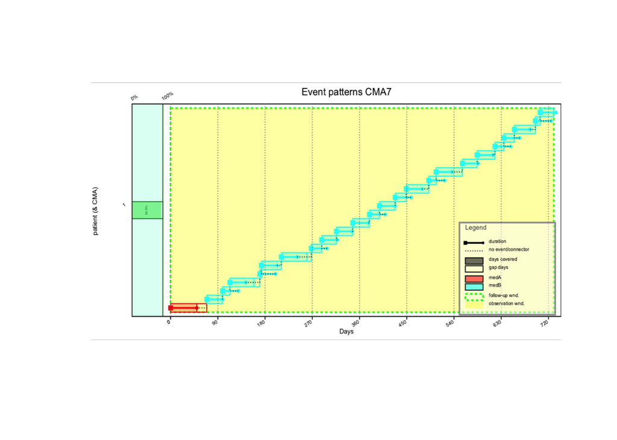

```r
# Save the JPEG stored as a BLOB to a temporary file and show it:
file_jpeg <- tempfile(pattern = "plot_blob_", tmpdir = tempdir(), fileext = ".jpg");
writeBin(d$plot_jpg[3][[1]], file_jpeg);
library(jpeg);
plot.new(); rasterImage(readJPEG(file_jpeg,native=TRUE),0,0,1,1);
```

while the (semi-)interactive HTML/CSS/JavaScript/SVG is saved as a ZIP archive which must be unpacked first (not shown here).

Finally, the row with `result_id` = 12 contains the results for a `sliding window`:

```r
d3 <- sqlQ(stu_db, "SELECT * FROM in_procs INNER JOIN in_actions INNER JOIN in_classes ON in_procs.procid = 10 AND in_procs.action_id = in_actions.action_id AND in_procs.medclass_id = in_classes.medclass_id ;");
d3$class <- gsub("`","&grave;",d3$class); # trick to show the backtick
d3[,c("procid", "pat_id", "medclass_id", "class", "action_id", "action", "params")]; # show the whole thing
```

| procid | pat_id | medclass_id | class | action_id | action | params |
| --- | --- | --- | --- | --- | --- | --- |
| 10 | 3 | * | * | pSW(CMA1,d=90,n=5) | plot.CMA_sliding_window | CMA.to.apply=“CMA1”, sliding.window.duration=90, sliding.window.no.steps=5 |

applied to all medications (`*`) for patient with id 3 (more precisely, we apply `CMA1` with the sliding window attributes defined in the `params` columns). Here we have the plots as well:

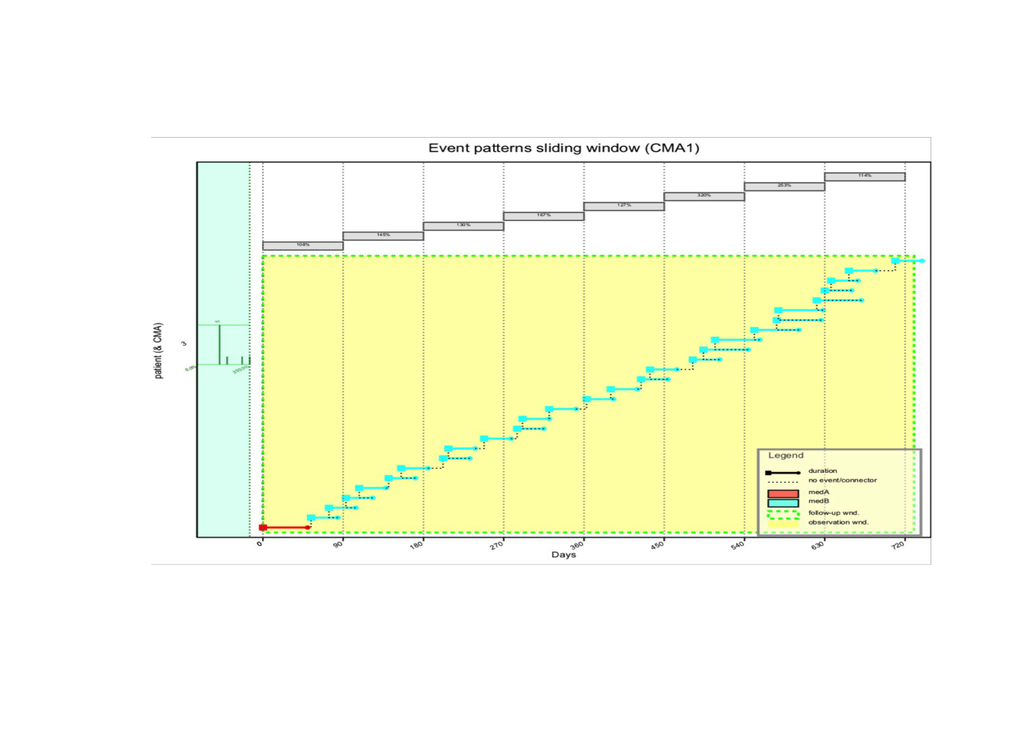

```r
file_jpeg <- tempfile(pattern = "plot_blob_", tmpdir = tempdir(), fileext = ".jpg");
writeBin(d$plot_jpg[12][[1]], file_jpeg);
plot.new(); rasterImage(readJPEG(file_jpeg,native=TRUE),0,0,1,1);
```

### The sliding windows results table

```r
# Look at the main results `res_slid_wnd` table (here called "out_res_slid_wnd", as per the YAML config file):
d4 <- sqlQ(stu_db, "SELECT * FROM out_res_slid_wnd LIMIT 15;");
d4;
```

| result_id | pat_id | window_id | window_start | window_end | estimate |
| --- | --- | --- | --- | --- | --- |
| 12 | 3 | 1 | 2042-04-13 | 2042-07-12 | 1.0811 |
| 12 | 3 | 2 | 2042-07-12 | 2042-10-10 | 1.4516 |
| 12 | 3 | 3 | 2042-10-10 | 2043-01-08 | 1.3043 |
| 12 | 3 | 4 | 2043-01-08 | 2043-04-08 | 1.6667 |
| 12 | 3 | 5 | 2043-04-08 | 2043-07-07 | 1.2676 |
| 12 | 3 | 6 | 2043-07-07 | 2043-10-05 | 3.2000 |
| 12 | 3 | 7 | 2043-10-05 | 2044-01-03 | 2.5316 |
| 12 | 3 | 8 | 2044-01-03 | 2044-04-02 | 1.1392 |

It can be seen that we have 8 rows pointing back to the main results `result_id` = 12, each describing one individual sliding window (including the corresponding estimate of the simple CMA).

### The per episode results table

This is interpreted just as the sliding windows results table decribed above, but for the per episode.

```r
# Look at the main results `res_per_epi` table (here called "out_res_per_epi", as per the YAML config file):
sqlQ(stu_db, "SELECT * FROM out_res_per_epi LIMIT 15;");
```

| result_id | pat_id | episode_id | episode_start | gap_days | episode_duration | episode_end | estimate |
| --- | --- | --- | --- | --- | --- | --- | --- |
| 18 | 4 | 1 | 2032-05-01 | 160 | 50 | 2032-06-20 | NA |
| 18 | 4 | 2 | 2032-11-27 | 216 | 50 | 2033-01-16 | NA |
| 18 | 4 | 3 | 2033-08-20 | 58 | 169 | 2034-02-05 | 0.8403 |
| 18 | 4 | 4 | 2034-04-04 | 0 | 27 | 2034-05-01 | NA |

## Conclusions

This proof-of-concept works decently fast for `MySQL`/`MariaDB`, Microsoft `SQL Server` and `SQLite`.

```r
# Disconnect from the database:
disconnect(stu_db);
```

```
## Disconnect: connection stopped...
```

## Extensions

There are several extensions and optimisations possible:

- a different mechanism for specifying which actions are to be applied to which events, using, for example, an extra table giving this info for each individual event
- now each patient is processed individually, which increases the number of interactions with the SQL server
- parallel processing of several patients
- …